# Lecture 8: PY 0782 - Advanced Quantitative Research Methods

2018-11-22 | disclaimer

## PY0782: Advanced Quantitative research methods.

- Last lecture: Exploratory Factor analysis
- Today: SEM I: Confirmatory Factor analysis.

## Goals (today)

Lavaan.

CFA sem.

Not: Make you a ‘sem’ expert. That would take an entire separate course, but you should be able to apply the basics and understand when you come across it.

## Assignment

After today you should be able to complete the following sections for Assignment II:

Confirmatory Factor Analysis via SEM.

## Last week.

Last week we covered exploratory factor analysis

Factor analysis is used to find a set of unobserved variables (latent variables / dimensions) which account for the covariance among a larger set of observed variables (manifest variables or indicators).

Basically, we have a large number of questions and we want to reduce the complexity.

Think back to the personality example of last week.

## Why is this useful?

Mostly: Questionnaire validation.

How many dimensions? Are they same or different across groups?

Can we drop questions?

Generate scores which discriminate between participants.

## EFA vs. CFA.

EFA has a lot of potential for ambiguous decisions. (How many to extract, How to extract, cut-offs for removing bad items.).

CFA forces you to make more explicit decisions. Explicit tests for which models are better.

## Terms.

Observed variable (indicator/manifest variable): it is something you measured.

Examples: a question on a happiness questionaire, a question about personality. Denoted with a rectangle.

Latent variable (construct/unobserved variable): we assume that these are the underlying variables causing people to score high or low on our observed variables.

Examples: Well-being, Openness, Intelligence. Denoted with a circle.

## More terms

Covariances: Denoted with double-headed arrows

Residuals: “the trash bag”, for which we can estimate the variance. We can allow them to be correlated or not. Useful to examine. Double-headed arrow to observed variable.

## How is it done?

Matrix algebra.

We can recast all proposed relations into a big matrix and then (attempt) to solve that matrix.

[figure not shown]

## Lavaan / sem

Outside of R there are specific packages which can do SEM, most notably MPLus, Lisrel, Latentgold, AMOS. But here you would have to leave SPSS for a different package.

There are also multiple packages in R which can do SEM (OpenMX, sem, Lavaan). Today we will focus on Lavaan.

## Example.

?HolzingerSwineford1939.

Data on children’s performance in two schools. (a subset)

[figure not shown]

## Notations in Lavaan.

Regressions: f= factor (latent variable)

y ~ f1 + f2 + x1 + x2

f1 ~ f2 + f3

f2 ~ f3 + x1 + x2

Factors.

f1 =~ y1 + y2 + y3

f2 =~ y4 + y5 + y6

f3 =~ y7 + y8 + y9 + y10

## Notations.

Double tildes for variance and covariances.

y1 ~~ y1 # variance

y1 ~~ y2 # covariance

f1 ~~ f2 # covariance

**Intercepts.**

1

y1 ~ 1

f1 ~ 1

## Back to our example.

visual =~ x1 + x2 + x3

textual =~ x4 + x5 + x6

speed =~ x7 + x8 + x9

[figure not shown]

## Our model in lavaan.

In order to define the model we place it in-between single (!) quotes. We can annotate with #

```r
setwd("~/Dropbox/Teaching_MRes_Northumbria/Lecture8")
require(lavaan)
Model_1 <- '  # Three factors.
              visual  =~ x1 + x2 + x3
              textual =~ x4 + x5 + x6
              speed   =~ x7 + x8 + x9 '
```

## Assumptions.

Before we move further: consider assumptions!

Basically, we are dealing with regressions (and factor analyses are a variant of that).

If there are no meaningful correlations, then it makes little sense to perform CFA. So one would usually examine or plot those. One way is to use the KMO test which we used last time.

```r
require(psych)
f_data<-(lavaan::HolzingerSwineford1939)[,c(7:15)]
KMO(f_data)
```

```
## Kaiser-Meyer-Olkin factor adequacy
## Call: KMO(r = f_data)
## Overall MSA =  0.75
## MSA for each item =
##   x1   x2   x3   x4   x5   x6   x7   x8   x9
## 0.81 0.78 0.73 0.76 0.74 0.81 0.59 0.68 0.79
```

## Assumptions.

Caution, not multivariate normal. One solution is robust estimation… . Maximum Likelihood (ML) more robust than some other methods but still cautious (affects standard errors of paths).

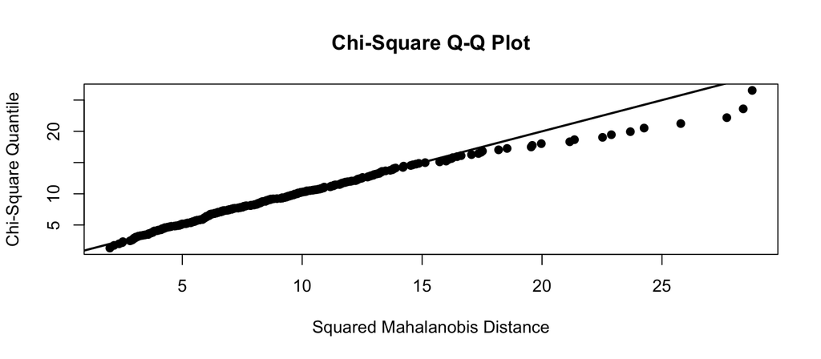

```
## $multivariateNormality
##              Test        Statistic              p value Result
## 1 Mardia Skewness 344.905276936947 8.86473544030093e-15     NO
## 2 Mardia Kurtosis 2.83021589156651  0.00465166039260279     NO
## 3             MVN             <NA>                 <NA>     NO
##
## $univariateNormality
##           Test  Variable Statistic   p value Normality
## 1 Shapiro-Wilk    x1        0.9928  0.1582      YES
## 2 Shapiro-Wilk    x2        0.9697  <0.001      NO
## 3 Shapiro-Wilk    x3        0.9523  <0.001      NO
## 4 Shapiro-Wilk    x4        0.9827  0.0011      NO
## 5 Shapiro-Wilk    x5        0.9769   1e-04      NO
## 6 Shapiro-Wilk    x6        0.9538  <0.001      NO
## 7 Shapiro-Wilk    x7        0.9908   0.056      YES
## 8 Shapiro-Wilk    x8        0.9807   4e-04      NO
## 9 Shapiro-Wilk    x9        0.9942   0.307      YES
##
## $Descriptives
##      n     Mean  Std.Dev   Median       Min       Max     25th     75th
## x1 301 4.935770 1.167432 5.000000 0.6666667  8.500000 4.166667 5.666667
## x2 301 6.088040 1.177451 6.000000 2.2500000  9.250000 5.250000 6.750000
## x3 301 2.250415 1.130979 2.125000 0.2500000  4.500000 1.375000 3.125000
## x4 301 3.060908 1.164116 3.000000 0.0000000  6.333333 2.333333 3.666667
## x5 301 4.340532 1.290472 4.500000 1.0000000  7.000000 3.500000 5.250000
## x6 301 2.185572 1.095603 2.000000 0.1428571  6.142857 1.428571 2.714286
## x7 301 4.185902 1.089534 4.086957 1.3043478  7.434783 3.478261 4.913043
## x8 301 5.527076 1.012615 5.500000 3.0500000 10.000000 4.850000 6.100000
## x9 301 5.374123 1.009152 5.416667 2.7777778  9.250000 4.750000 6.083333
##          Skew    Kurtosis
## x1 -0.2543455  0.30753382
## x2  0.4700766  0.33239397
## x3  0.3834294 -0.90752645
## x4  0.2674867  0.08012676
## x5 -0.3497961 -0.55253689
## x6  0.8579486  0.81655717
## x7  0.2490881 -0.30740386
## x8  0.5252580  1.17155564
## x9  0.2038709  0.28990791
```

```r
require(MVN)
mvn(f_data, multivariatePlot = "qq")
```

## Test.

```r
require(MVN)
mvn(f_data)
```

```
## $multivariateNormality
##              Test        Statistic              p value Result
## 1 Mardia Skewness 344.905276936947 8.86473544030093e-15     NO
## 2 Mardia Kurtosis 2.83021589156651  0.00465166039260279     NO
## 3             MVN             <NA>                 <NA>     NO
##
## $univariateNormality
##           Test  Variable Statistic   p value Normality
## 1 Shapiro-Wilk    x1        0.9928  0.1582      YES
## 2 Shapiro-Wilk    x2        0.9697  <0.001      NO
## 3 Shapiro-Wilk    x3        0.9523  <0.001      NO
## 4 Shapiro-Wilk    x4        0.9827  0.0011      NO
## 5 Shapiro-Wilk    x5        0.9769   1e-04      NO
## 6 Shapiro-Wilk    x6        0.9538  <0.001      NO
## 7 Shapiro-Wilk    x7        0.9908   0.056      YES
## 8 Shapiro-Wilk    x8        0.9807   4e-04      NO
## 9 Shapiro-Wilk    x9        0.9942   0.307      YES
##
## $Descriptives
##      n     Mean  Std.Dev   Median       Min       Max     25th     75th
## x1 301 4.935770 1.167432 5.000000 0.6666667  8.500000 4.166667 5.666667
## x2 301 6.088040 1.177451 6.000000 2.2500000  9.250000 5.250000 6.750000
## x3 301 2.250415 1.130979 2.125000 0.2500000  4.500000 1.375000 3.125000
## x4 301 3.060908 1.164116 3.000000 0.0000000  6.333333 2.333333 3.666667
## x5 301 4.340532 1.290472 4.500000 1.0000000  7.000000 3.500000 5.250000
## x6 301 2.185572 1.095603 2.000000 0.1428571  6.142857 1.428571 2.714286
## x7 301 4.185902 1.089534 4.086957 1.3043478  7.434783 3.478261 4.913043
## x8 301 5.527076 1.012615 5.500000 3.0500000 10.000000 4.850000 6.100000
## x9 301 5.374123 1.009152 5.416667 2.7777778  9.250000 4.750000 6.083333
##          Skew    Kurtosis
## x1 -0.2543455  0.30753382
## x2  0.4700766  0.33239397
## x3  0.3834294 -0.90752645
## x4  0.2674867  0.08012676
## x5 -0.3497961 -0.55253689
## x6  0.8579486  0.81655717
## x7  0.2490881 -0.30740386
## x8  0.5252580  1.17155564
## x9  0.2038709  0.28990791
```

## CFA

```r
require(lavaan)
fit <- cfa(Model_1, data=HolzingerSwineford1939)
sink(file = 'summary_fit.txt')
summary(fit, fit.measures=TRUE)
```

```
## lavaan 0.6-3 ended normally after 35 iterations
##
##   Optimization method                           NLMINB
##   Number of free parameters                         21
##
##   Number of observations                           301
##
##   Estimator                                         ML
##   Model Fit Test Statistic                      85.306
##   Degrees of freedom                                24
##   P-value (Chi-square)                           0.000
##
## Model test baseline model:
##
##   Minimum Function Test Statistic              918.852
##   Degrees of freedom                                36
##   P-value                                        0.000
##
## User model versus baseline model:
##
##   Comparative Fit Index (CFI)                    0.931
##   Tucker-Lewis Index (TLI)                       0.896
##
## Loglikelihood and Information Criteria:
##
##   Loglikelihood user model (H0)              -3737.745
##   Loglikelihood unrestricted model (H1)      -3695.092
##
##   Number of free parameters                         21
##   Akaike (AIC)                                7517.490
##   Bayesian (BIC)                              7595.339
##   Sample-size adjusted Bayesian (BIC)         7528.739
##
## Root Mean Square Error of Approximation:
##
##   RMSEA                                          0.092
##   90 Percent Confidence Interval          0.071  0.114
##   P-value RMSEA <= 0.05                          0.001
##
## Standardized Root Mean Square Residual:
```

[output cut: 31 more lines]

```
##
## Variances:
##                    Estimate  Std.Err  z-value  P(>|z|)
##    .x1                0.549    0.114    4.833    0.000
##    .x2                1.134    0.102   11.146    0.000
##    .x3                0.844    0.091    9.317    0.000
##    .x4                0.371    0.048    7.779    0.000
##    .x5                0.446    0.058    7.642    0.000
##    .x6                0.356    0.043    8.277    0.000
##    .x7                0.799    0.081    9.823    0.000
##    .x8                0.488    0.074    6.573    0.000
##    .x9                0.566    0.071    8.003    0.000
##     visual            0.809    0.145    5.564    0.000
##     textual           0.979    0.112    8.737    0.000
##     speed             0.384    0.086    4.451    0.000
```

```r
sink()
```

## Some familiar faces… .

The TLI suggested an acceptable fit (.9), as did the CFI (.93). However, the RMSEA (.092) suggested a relatively poor fit with a 90%CI ranging from .071 to .114.

The CFI is another fit measure, some argue >.9, some argue >.95. read more [here](http://www.ejbrm.com/issue/download.html?idArticle=183).

Many measures exist, most commonly reported RMSEA,CFI,TLI

[figure not shown]

## Try it yourself.

Return to last week’s model which we tested in class. (If you failed to save your datafile, you can download it again from [here](https://stats.idre.ucla.edu/wp-content/uploads/2016/02/M255.sav))

Write a three factor model in lavaan’s format and evaluate the fit measures.

[figure not shown]

## Visualise and interpret.

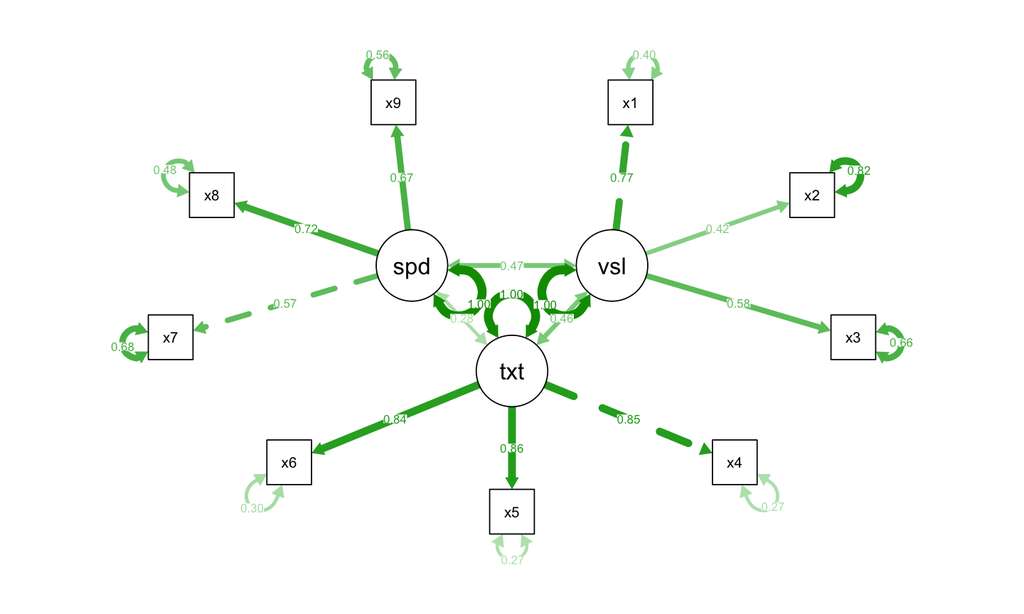

```r
require(semPlot)
semPaths(fit, layout = "circle", style = "ram", what = "std")
```

## Lisrel style plot.

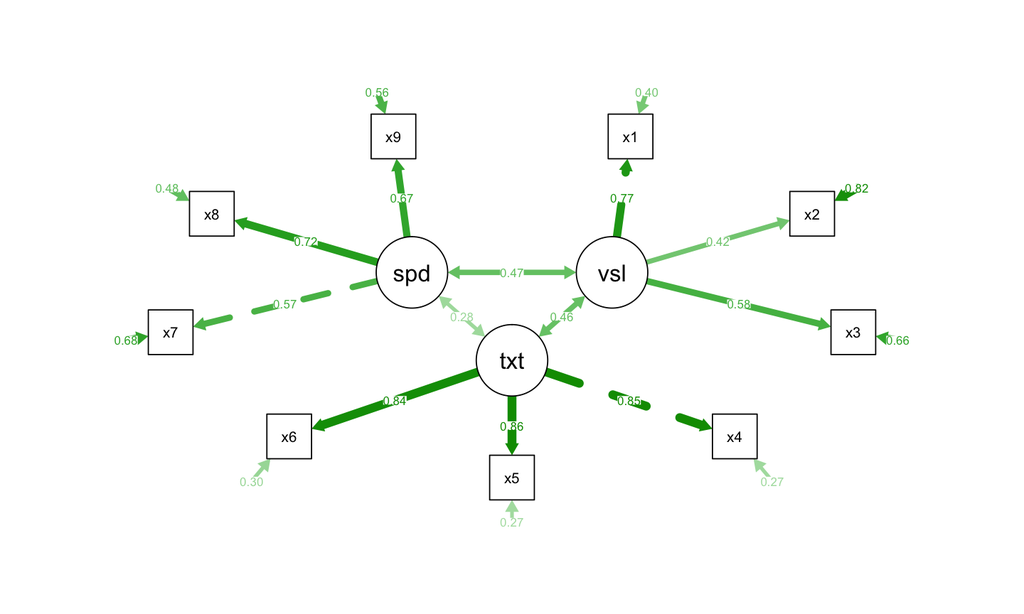

```r
semPaths(fit, layout='circle',style = "lisrel",what="std")
```

## Try it yourself!

Make a plot of your three-factor model.

[figure not shown]

## Export a table

```r
require(dplyr)
require(stargazer)
results_table <- parameterEstimates(fit, standardized = TRUE) %>%
    filter(op == "=~") %>% dplyr::select(`Latent Factor` = lhs,
    Indicator = rhs, B = est, SE = se, Z = z, `p value` = pvalue,
    Beta = std.all)
# export via stargazer. (Other options are
# ??xtable)
stargazer(results_table, summary = FALSE, out = "results_table.html",
    header = F)
```

```
##
## \begin{table}[!htbp] \centering
##   \caption{}
##   \label{}
## \begin{tabular}{@{\extracolsep{5pt}} cccccccc}
## \\[-1.8ex]\hline
## \hline \\[-1.8ex]
##  & Latent Factor & Indicator & B & SE & Z & p value & Beta \\
## \hline \\[-1.8ex]
## 1 & visual & x1 & $1$ & $0$ & $$ & $$ & $0.772$ \\
## 2 & visual & x2 & $0.554$ & $0.100$ & $5.554$ & $0.00000$ & $0.424$ \\
## 3 & visual & x3 & $0.729$ & $0.109$ & $6.685$ & $0$ & $0.581$ \\
## 4 & textual & x4 & $1$ & $0$ & $$ & $$ & $0.852$ \\
## 5 & textual & x5 & $1.113$ & $0.065$ & $17.014$ & $0$ & $0.855$ \\
## 6 & textual & x6 & $0.926$ & $0.055$ & $16.703$ & $0$ & $0.838$ \\
## 7 & speed & x7 & $1$ & $0$ & $$ & $$ & $0.570$ \\
## 8 & speed & x8 & $1.180$ & $0.165$ & $7.152$ & $0$ & $0.723$ \\
## 9 & speed & x9 & $1.082$ & $0.151$ & $7.155$ & $0$ & $0.665$ \\
## \hline \\[-1.8ex]
## \end{tabular}
## \end{table}
```

## Interpretation.

Most load above >.45 and quite high. Hurray!

Some further decision rules: [here](http://imaging.mrc-cbu.cam.ac.uk/statswiki/FAQ/thresholds)

Some rules of thumb for factor loadings: some use .4 or .5 as a cut-off, others argue for this range 0.32 (poor), 0.45 (fair), 0.55 (good), 0.63 (very good) or 0.71 (excellent), but beware of cut-offs in general.

## Residuals check.

Mostly weak to no correlations (<.3 in absolute size). Hurray, again!

You could also still check the distributions of those.

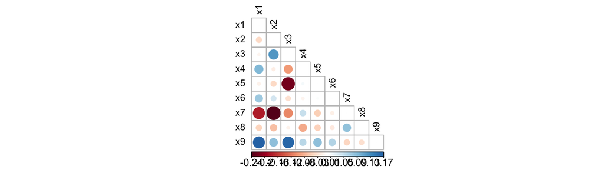

```r
require(ggplot2)
require(corrplot)
plot_matrix <- function(matrix_toplot){
corrplot(matrix_toplot, is.corr = FALSE,
               type = 'lower',
               order = "original",
               tl.col='black', tl.cex=.75)}
plot_matrix(residuals(fit)$cov)
```

## Single factor model.

```r
require(lavaan)
Model_2 <- '  # one factor.
              ability  =~ x1 + x2 + x3 + x4 + x5 + x6 + x7 + x8 + x9 '
```

## Text output.

```r
fit_model_2<-cfa(Model_2, data= HolzingerSwineford1939)
sink(file="summary_fit_2.txt")
summary(fit_model_2, fit.measures=T)
```

```
## lavaan 0.6-3 ended normally after 31 iterations
##
##   Optimization method                           NLMINB
##   Number of free parameters                         18
##
##   Number of observations                           301
##
##   Estimator                                         ML
##   Model Fit Test Statistic                     312.264
##   Degrees of freedom                                27
##   P-value (Chi-square)                           0.000
##
## Model test baseline model:
##
##   Minimum Function Test Statistic              918.852
##   Degrees of freedom                                36
##   P-value                                        0.000
##
## User model versus baseline model:
##
##   Comparative Fit Index (CFI)                    0.677
##   Tucker-Lewis Index (TLI)                       0.569
##
## Loglikelihood and Information Criteria:
##
##   Loglikelihood user model (H0)              -3851.224
##   Loglikelihood unrestricted model (H1)      -3695.092
##
##   Number of free parameters                         18
##   Akaike (AIC)                                7738.448
##   Bayesian (BIC)                              7805.176
##   Sample-size adjusted Bayesian (BIC)         7748.091
##
## Root Mean Square Error of Approximation:
##
##   RMSEA                                          0.187
##   90 Percent Confidence Interval          0.169  0.206
##   P-value RMSEA <= 0.05                          0.000
##
## Standardized Root Mean Square Residual:
```

[output cut: 19 more lines]

```
##     x8                0.398    0.129    3.089    0.002
##     x9                0.606    0.138    4.383    0.000
##
## Variances:
##                    Estimate  Std.Err  z-value  P(>|z|)
##    .x1                1.098    0.092   11.895    0.000
##    .x2                1.315    0.108   12.188    0.000
##    .x3                1.212    0.099   12.186    0.000
##    .x4                0.380    0.048    7.963    0.000
##    .x5                0.486    0.059    8.193    0.000
##    .x6                0.356    0.043    8.295    0.000
##    .x7                1.145    0.094   12.215    0.000
##    .x8                0.981    0.080   12.202    0.000
##    .x9                0.919    0.076   12.105    0.000
##     ability           0.261    0.069    3.775    0.000
```

```r
sink()
```

## Compare fit.

AIC and BIC are fit indices. BIC (Bayesian Information Criterion) penalizes model complexity more harshly than AIC.

Lower is better. (The rationale is information theory, which you can read about [here](http://ecologia.ib.usp.br/bie5782/lib/exe/fetch.php?media=bie5782:pdfs:burnham_anderson2002.pdf))

Many guidelines on fit indices, read more [here](http://ecologia.ib.usp.br/bie5782/lib/exe/fetch.php?media=bie5782:pdfs:burnham_anderson2002.pdf).

You can also generate [AIC weights](http://ejwagenmakers.com/2004/aic.pdf).

## Interpretation.

Some rules of thumb from Kass & Raftery (1995) (based on BIC). (Again apply sensibly… .)

0 to 2: Not worth more than a bare mention

2 to 6: Positive

6 to 10: Strong

>10: Very Strong

## Fit.

A model with three factors is a better fit to the data than one with a single factor in terms of AIC and BIC (both \(\Delta\geq\) 205).

–> this means overwhelming support for the three factor solution.

```r
anova(fit,fit_model_2)
```

```
## Chi Square Difference Test
##
##             Df    AIC    BIC   Chisq Chisq diff Df diff Pr(>Chisq)
## fit         24 7517.5 7595.3  85.305
## fit_model_2 27 7738.4 7805.2 312.264     226.96       3  < 2.2e-16 ***
## ---
## Signif. codes:  0 '***' 0.001 '**' 0.01 '*' 0.05 '.' 0.1 ' ' 1
```

## Try it yourself.

Make a one factor model for the Sidanius data.

Compare the fit of that model to a three-factor model. What do you conclude?

## Measurement invariance?

Have you heard of the term?

Can you think of situations where it would be useful?

## Measurement invariance.

Is the pattern the same for certain groups? Read more [here](http://www.tandfonline.com/doi/abs/10.1080/17405629.2012.686740)

1. Equal form: The number of factors and the pattern of factor-indicator relationships are identical across groups.
2. Equal loadings: Factor loadings are equal across groups.
3. Equal intercepts: When observed scores are regressed on each factor, the intercepts are equal across groups.
4. Equal residual variances: The residual variances of the observed scores not accounted for by the factors are equal across groups

–> all 4 satisfied: **strict** measurement invariance. This does not always happen.

## Our example.

Let’s compare if the three-factor structure is the same in both schools.

Basically: Is the measurement in both schools the same?

[figure not shown]

## Group model

```r
require(lavaan)
Data<- HolzingerSwineford1939
Group_model_1 <- '  # Three factors.
              visual  =~ x1 + x2 + x3
              textual =~ x4 + x5 + x6
              speed   =~ x7 + x8 + x9 '
fit_CFA_group<-cfa(Group_model_1, data= Data, group="school")
```

## Massive output!

```r
sink(file = 'group_cfa.txt')
summary(fit_CFA_group, fit.measures=T)
sink()
```

[figure not shown]

## Plot.

Combined groups plot.

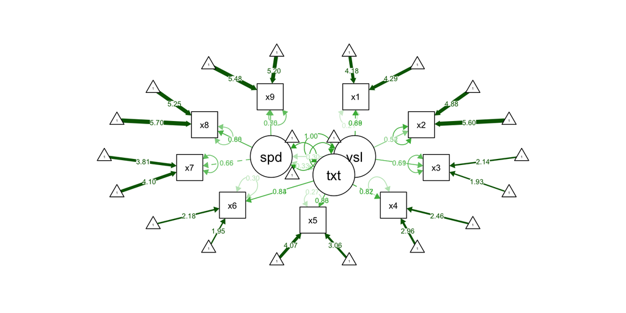

```r
require(semPlot)
require(qgraph)
semPaths(fit_CFA_group, layout='circle',style = "ram",what="std", combineGroups=T)
```

## Separate plots

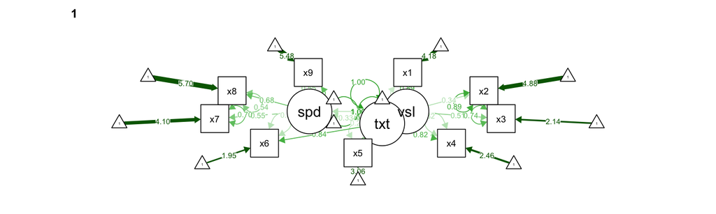

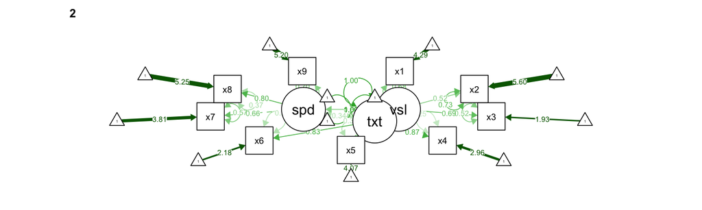

```r
require(semPlot)
require(qgraph)
semPaths(fit_CFA_group, layout='circle',style = "ram",what="std", combineGroups=F)
```

## Measurement Invariance

```r
require(semTools)
semTools::measurementInvariance(model = Group_model_1,
    data = Data, group = "school")
```

```
##
## Measurement invariance models:
##
## Model 1 : fit.configural
## Model 2 : fit.loadings
## Model 3 : fit.intercepts
## Model 4 : fit.means
##
## Chi Square Difference Test
##
##                Df    AIC    BIC  Chisq Chisq diff Df diff Pr(>Chisq)
## fit.configural 48 7484.4 7706.8 115.85
## fit.loadings   54 7480.6 7680.8 124.04      8.192       6     0.2244
## fit.intercepts 60 7508.6 7686.6 164.10     40.059       6  4.435e-07 ***
## fit.means      63 7543.1 7710.0 204.61     40.502       3  8.338e-09 ***
## ---
## Signif. codes:  0 '***' 0.001 '**' 0.01 '*' 0.05 '.' 0.1 ' ' 1
##
##
## Fit measures:
##
##                  cfi rmsea cfi.delta rmsea.delta
## fit.configural 0.923 0.097        NA          NA
## fit.loadings   0.921 0.093     0.002       0.004
## fit.intercepts 0.882 0.107     0.038       0.015
## fit.means      0.840 0.122     0.042       0.015
```

## Terminology.

Model 2: Metric invariance: “Respondents across groups attribute the same meaning to the latent construct under study”

Model 3: Scalar invariance: “implies that the meaning of the construct (the factor loadings), and the levels of the underlying items (intercepts) are equal in both groups. Consequently, groups can be compared on their scores on the latent variable.”

More [here](http://users.ugent.be/~yrosseel/lavaan/multiplegroup6Dec2012.pdf) and [here](http://www.tandfonline.com/doi/abs/10.1080/17405629.2012.686740)

## Table.

Stargazer won’t change labels! See if you can figure out a solution :). it cost me a day… .

```r
require(psytabs)
require(stargazer)
MI <- measurementInvariance(model = Group_model_1, data = Data,
    group = "school")
tab.1 <- measurementInvarianceTable(MI)
stargazer(tab.1, summary = F, type = "html", dep.var.labels = c("$\\chi^2$",
    "df", "$\\Delta$\\chi^2$", "df", "p", "CFI", "$\\Delta$CFI",
    "RMSEA", "$\\Delta$RMSEA", "BIC", "$\\Delta$BIC"), out = "Measurement invariance.html",
    header = F)
```

## Sample write up.

In conclusion: Metric Invariance in this case: “the meaning is the same across both groups”.

## Partial invariance.

It is possible that the lack of measurement invariance is caused by issues with just one or two items. In such a case, we could allow those to ‘vary’ between the groups.

You can read more [here](http://users.ugent.be/~yrosseel/lavaan/multiplegroup6Dec2012.pdf)

## Exercise

Using the ‘bfi’ data from the ‘psych’ package, build a five factor model using lavaan.

Discuss the CFI, RMSEA and TLI of that model. Export a table with the factor loadings.

Make a plot.

Compare the fit of a five factor model to a single factor model (“The general factor of personality”).

## Exercise (cont’d)

Test the measurement invariance for men vs. women in the five factor model. Make a plot.

Make a table and discuss.

## References (and further reading.)

Also check the reading list! (many more than listed here).

- Hoyle, R. H. (ed.) (2014). *Handbook of Structural Equation Modelling.* London: Guilford.
- Loehlin, J. C., & Beaujean, A. A. (2017). *Latent variable models: An introduction to factor, path, and structural equation analysis*. London: Taylor & Francis.
- Rosseel, Y. (2012). lavaan: An R Package for Structural Equation Modeling. *Journal of Statistical Software, 48(2)*, 1-36. also [see this](http://lavaan.ugent.be).
- Stochl, J. (2010). *Confirmatory factor analysis in MPlus.* https://www.psychometrics.cam.ac.uk/uploads/documents/ESRC_RDI_June10/rdicfastochljune2010.pdf
- Templin, J. (2011). *Introduction to Confirmatory Factor Analysis and Structural Equation Modeling* https://jonathantemplin.com/files/multivariate/mv11icpsr/mv11icpsr_lecture12.pdf
- Van de Schoot, R., Lugtig, P., & Hox, J. (2012). A checklist for testing measurement invariance. *European Journal of Developmental Psychology*, 9(4), 486–492.
- van de Schoot, R. & Schalken, N. (2017). Lavaan: how to get started. https://www.rensvandeschoot.com/tutorials/lavaan-how-to-get-started/
- Tabachnick BG, Fidell LS. (2007) *Using Multivariate Statistics.* Boston: Pearson Education.